# R Notebook

```r
library(tidyverse)
library(lme4)
library(ggpubr)

source("helpers.R")
```

```r
bran_palette = c("#7ae7e5","#B2A6DE", "#fe5f55", "#14342b", "#69385c")

theme_set(theme_minimal())
```

```r
lex_freqs <- read.csv("freq_preped.csv") %>%
  mutate(left_surprisal = (-log(mean_left_neutral))/(-log(mean_left_gendered))) %>%
  mutate(right_surprisal = (-log(mean_right_neutral))/(-log(mean_right_gendered)))
```

```r
gender_transcendence_cols <- c('subject_information.gender_q1','subject_information.gender_q2','subject_information.gender_q3','subject_information.gender_q4','subject_information.gender_q5')

gender_linked_cols <- c('subject_information.gender_q6','subject_information.gender_q7','subject_information.gender_q8','subject_information.gender_q9','subject_information.gender_q10','subject_information.gender_q11','subject_information.gender_q12','subject_information.gender_q13')
```

**Data Read-in**

```r
maze_data <- read.csv('maze_data.csv') %>%
  filter(trial_id!= 'example') %>%
  filter(region=='critical')
```

```r
maze_data %>%
  group_by(workerid) %>%
  summarise(workerid=paste(unique(workerid))) %>%
  nrow()
```

```
[1] 198
```

**Running Exclusion Criteria** Now, we want to exclude any participants who failed to answer at least 80% of the attention check questions correctly. We do this by creating a list of all participants who scored less than 80% on these checks, and then cross-referencing this list with all data points, removing any data points whose participants were in the exclusion list.

```r
maze_exclusion <- maze_data %>% group_by(workerid) %>%
  summarise(accuracy = mean(response_correct)) %>%
  mutate(exclude = ifelse(accuracy < 0.80,'Yes','No')) %>%
  filter(exclude == 'Yes')

maze_data <- maze_data[!(maze_data$workerid %in% maze_exclusion$workerid),] %>%
  filter(rt !='null')
```

```r
maze_data <- maze_data %>%
  group_by(trial_id) %>%
  mutate(id_mean = mean(log(rt))) %>%
  mutate(exclusion = (log(rt) < mean(log(rt)) - 2*sd(log(rt))|(log(rt) > mean(log(rt)) + 2*sd(log(rt))))) %>%
  ungroup() %>%
  filter(exclusion==FALSE)
```

**Additional Information**

```r
maze_data <- maze_data %>%
  mutate(gender_trans = 100 - (rowMeans(maze_data[gender_transcendence_cols]))) %>%
  mutate(gender_link = rowMeans(maze_data[gender_linked_cols]))

gender_all = c('gender_trans','gender_link')

maze_data <- maze_data %>%
  mutate(gender_total = rowMeans(maze_data[gender_all]))
```

### Adding Gender

We also want to add whether the trial included a female or male referent (but also, like, destroy the binary!). In order to do this, we’ll just add a **trial_gender** column that says *‘female’* if the condition was either *‘neutral_female’* or *‘congruent_female’*. Otherwise, we want the **trial_gender** to say *‘male’*.

```r
maze_data <- maze_data %>%
  mutate(trial_gender = ifelse(condition=='neutral_female' | condition == 'congruent_female','female','male'))

maze_data %>%
  select(workerid,rt,condition,trial_id,trial_gender)
```

| workerid | rt | condition | trial_id | trial_gender |
| --- | --- | --- | --- | --- |
| 489 | 2532 | neutral_female | congressperson_neutral_female | female |
| 489 | 1526 | congruent_male | meteorologist_congruent_male | male |
| 489 | 1504 | congruent_male | layperson_congruent_male | male |
| 489 | 1305 | congruent_female | anchor_congruent_female | female |
| 489 | 1155 | congruent_female | foreperson_congruent_female | female |
| 489 | 1154 | congruent_female | businessperson_congruent_female | female |
| 489 | 1225 | congruent_male | host_congruent_male | male |
| 489 | 1973 | congruent_female | craftsperson_congruent_female | female |
| 489 | 1467 | congruent_male | stunt double_congruent_male | male |
| 489 | 2211 | neutral_male | police officer_neutral_male | male |

[output cut: 990 more lines]

### Adding Morphology Type

Now we want to add whether or not the lexeme’s neutral form is developed by compounding (as in *‘congress-person’*) or by the adoption of the male form (as in *‘actor’* being used more for both men and women). In this study, we only have six lexemes of the latter type, so we’ll just tell R to assign those a **morph_type** value of *‘adoption’* (for ‘male adoption’), and all else will be assigned a value of *‘compound’*.

```r
maze_data <- maze_data%>%
  mutate(morph_type = ifelse(lexeme!= 'actor' & lexeme!= 'host' & lexeme !='hunter' & lexeme!= 'villain' & lexeme!= 'heir' & lexeme!= 'hero','compound','adoption'))

maze_data %>%
  select(rt,lexeme,morph_type)
```

| rt | lexeme | morph_type |
| --- | --- | --- |
| 2532 | congressperson | compound |
| 1526 | meteorologist | compound |
| 1504 | layperson | compound |
| 1305 | anchor | compound |
| 1155 | foreperson | compound |
| 1154 | businessperson | compound |
| 1225 | host | adoption |
| 1973 | craftsperson | compound |
| 1467 | stunt double | compound |
| 2211 | police officer | compound |

[output cut: 990 more lines]

### Adding Form Length & Length-Controlled Residuals

Another important factor we want to explore is the length of the critical item! In order to add this, we simply create a new column **form_length** and tell R to input as that column’s value the length of the string that appears in that row’s **form** column, which corresponds to the orthograpic form of the critical item in that trial. *Note that this will include spaces in the count!*

```r
maze_data <- maze_data %>%
  mutate(form_length = str_length(form))

simple_model <- lm(log(rt)~form_length, data = maze_data)

maze_data <- maze_data %>%
  mutate(resid_rt = resid(simple_model))
```

```r
summary(simple_model)
```

```
Call:
lm(formula = log(rt) ~ form_length, data = maze_data)

Residuals:
     Min       1Q   Median       3Q      Max
-0.83975 -0.27384 -0.05032  0.23306  1.56914

Coefficients:
            Estimate Std. Error t value Pr(>|t|)
(Intercept)  6.92941    0.01911 362.644  < 2e-16 ***
form_length  0.01099    0.00196   5.608 2.21e-08 ***
---
Signif. codes:  0 ‘***’ 0.001 ‘**’ 0.01 ‘*’ 0.05 ‘.’ 0.1 ‘ ’ 1

Residual standard error: 0.3638 on 3269 degrees of freedom
Multiple R-squared:  0.00953,   Adjusted R-squared:  0.009227
F-statistic: 31.45 on 1 and 3269 DF,  p-value: 2.212e-08
```

Now that we have these, we can run a simple linear regression which will show us the effect of orthographic length on reading time. Then we add a new column in the data which is the residual reading time, or the reading time in log space AFTER we control for the effects of orthographic length.

### Adding Congruency Column

We also want to make sure we have a column which records whether or not the trial was gender-congruent (as in *‘Shelby is a congresswoman’*) or gender neutral (as in *‘Shelby is a congressperson’*). We add a **trial_congruency** column, which is valued as *‘congruent’* if that row’s condition is one of the two congruent conditions. Otherwise, it gets valued as *‘neutral’*.

```r
maze_data <- maze_data %>%
  mutate(trial_congruency = ifelse(condition=='congruent_male' | condition == 'congruent_female','congruent','neutral'))
```

### Adding Large Political Macrocategories

Finally, we can classify participants by their particular political alignment; we can construe this broadly as “Republicans” vs. “Democrats”, with those who declined to state a preference, or placed themselves in the middle, as “Non-Partisan”.

```r
maze_data <- maze_data %>%
  mutate(poli_party = ifelse(subject_information.party_alignment == 1 | subject_information.party_alignment == 2,'Republican',ifelse(subject_information.party_alignment == 4 | subject_information.party_alignment == 5,'Democrat','Non-Partisan')))
```

```r
maze_data_means_all <- maze_data %>%
  filter(!is.na(poli_party)) %>%
  group_by(condition,workerid,poli_party,gender_total) %>%
  summarise(condition_mean = mean(resid_rt))
```

**Visualisations**

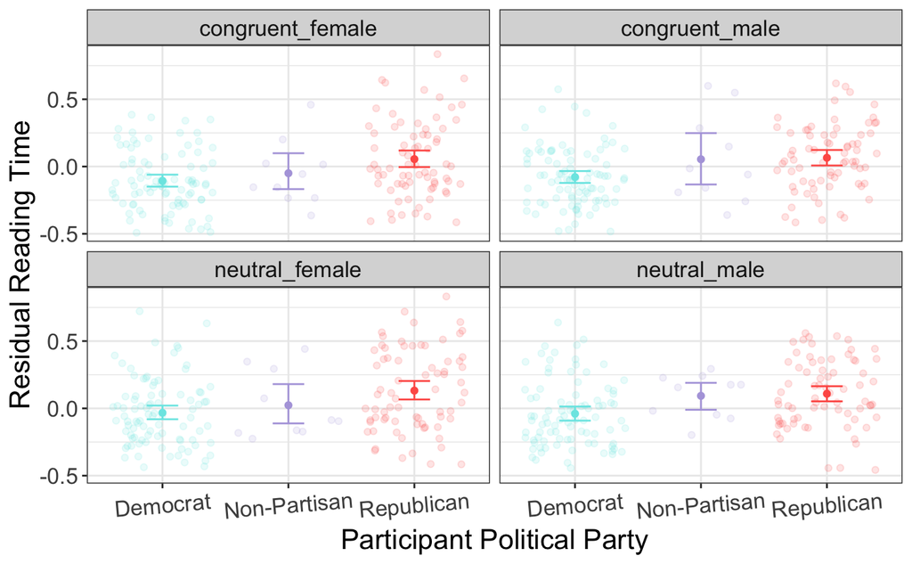

```r
maze_data_means_all %>%
  filter(!is.na(poli_party)) %>%
  #filter(poli_party != "Non-Partisan") %>%
  group_by(condition,poli_party) %>%
  summarize(mean_rt = mean(condition_mean), CI.Low = ci.low(condition_mean), CI.High = ci.high(condition_mean)) %>%
  mutate(YMin = mean_rt - CI.Low, YMax = mean_rt + CI.High) %>%
  ggplot(aes(x=poli_party,y=mean_rt,color=poli_party)) +
  geom_point() +
  geom_point(data=maze_data_means_all, aes(x=poli_party,y=condition_mean),alpha=0.15, position="jitter") +
  geom_errorbar(aes(ymin=YMin,ymax=YMax),width=.25) +
  facet_wrap(~ condition) +
  theme_bw() +
  labs(x="Participant Political Party", y="Residual Reading Time") +
  theme(text=element_text(size=16)) +
  theme(axis.text.x = element_text(angle=5, vjust = .7)) +
  scale_color_manual(values = bran_palette) +
  theme(legend.position = "none")
```

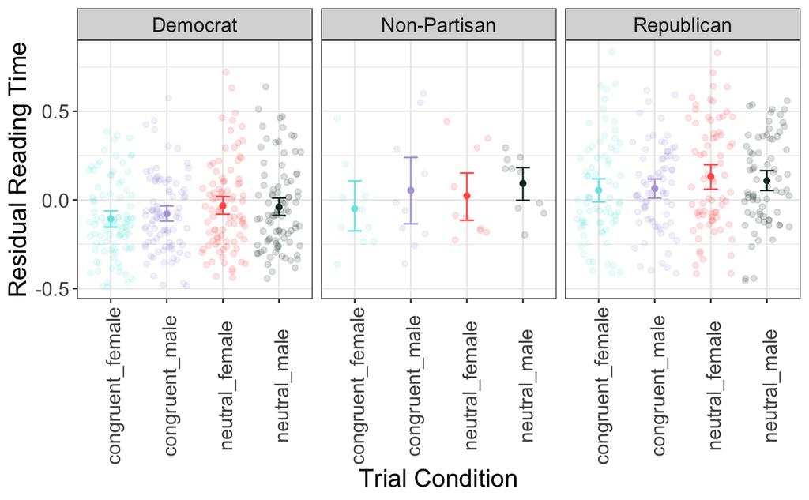

```r
maze_data_means_all %>%
  filter(!is.na(poli_party)) %>%
  #filter(poli_party != "Non-Partisan") %>%
  group_by(condition,poli_party) %>%
  summarize(mean_rt = mean(condition_mean), CI.Low = ci.low(condition_mean), CI.High = ci.high(condition_mean)) %>%
  mutate(YMin = mean_rt - CI.Low, YMax = mean_rt + CI.High) %>%
  ggplot(aes(x=condition,y=mean_rt,color=condition)) +
  geom_point() +
  geom_point(data=maze_data_means_all, aes(x=condition,y=condition_mean),alpha=0.15, position="jitter") +
  geom_errorbar(aes(ymin=YMin,ymax=YMax),width=.25) +
  facet_wrap(~ poli_party) +
  theme_bw() +
  labs(x="Trial Condition", y="Residual Reading Time") +
  theme(text=element_text(size=16)) +
  theme(axis.text.x = element_text(angle=90, vjust = .7)) +
  scale_color_manual(values = bran_palette) +
  theme(legend.position = "none")
```

# With All Regions

**Data Read-in**

```r
maze_data_comp <- read.csv('maze_data.csv') %>%
  filter(region=="none")
```

```r
maze_data_comp %>%
  group_by(workerid) %>%
  summarise(workerid=paste(unique(workerid))) %>%
  nrow()
```

```
[1] 198
```

**Running Exclusion Criteria** Now, we want to exclude any participants who failed to answer at least 80% of the attention check questions correctly. We do this by creating a list of all participants who scored less than 80% on these checks, and then cross-referencing this list with all data points, removing any data points whose participants were in the exclusion list.

```r
maze_exclusion <- maze_data_comp %>% group_by(workerid) %>%
  summarise(accuracy = mean(response_correct)) %>%
  mutate(exclude = ifelse(accuracy < 0.80,'Yes','No')) %>%
  filter(exclude == 'Yes')

maze_data_comp <- maze_data_comp[!(maze_data_comp$workerid %in% maze_exclusion$workerid),] %>%
  filter(rt !='null')
```

```r
maze_data_comp <- maze_data_comp %>%
  group_by(trial_id) %>%
  mutate(id_mean = mean(log(rt))) %>%
  mutate(exclusion = (log(rt) < mean(log(rt)) - 2*sd(log(rt))|(log(rt) > mean(log(rt)) + 2*sd(log(rt))))) %>%
  ungroup() %>%
  filter(exclusion==FALSE)
```

**Additional Information**

```r
maze_data_comp <- maze_data_comp %>%
  mutate(gender_trans = 100 - (rowMeans(maze_data_comp[gender_transcendence_cols]))) %>%
  mutate(gender_link = rowMeans(maze_data_comp[gender_linked_cols]))

gender_all = c('gender_trans','gender_link')

maze_data_comp <- maze_data_comp %>%
  mutate(gender_total = rowMeans(maze_data_comp[gender_all]))
```

### Adding Gender

We also want to add whether the trial included a female or male referent (but also, like, destroy the binary!). In order to do this, we’ll just add a **trial_gender** column that says *‘female’* if the condition was either *‘neutral_female’* or *‘congruent_female’*. Otherwise, we want the **trial_gender** to say *‘male’*.

```r
maze_data_comp <- maze_data_comp %>%
  mutate(trial_gender = ifelse(condition=='neutral_female' | condition == 'congruent_female','female','male'))

maze_data_comp %>%
  select(workerid,rt,condition,trial_id,trial_gender)
```

| workerid | rt | condition | trial_id | trial_gender |
| --- | --- | --- | --- | --- |
| 489 | 2752 | neutral_female | example | female |
| 489 | 3062 | neutral_female | example | female |
| 489 | 1287 | neutral_female | example | female |
| 489 | 1386 | neutral_female | example | female |
| 489 | 1503 | neutral_female | example | female |
| 489 | 1298 | neutral_female | example | female |
| 489 | 1163 | neutral_female | example | female |
| 489 | 1179 | neutral_female | example | female |
| 489 | 1395 | neutral_male | example | male |
| 489 | 1129 | neutral_male | example | male |

[output cut: 990 more lines]

### Adding Morphology Type

Now we want to add whether or not the lexeme’s neutral form is developed by compounding (as in *‘congress-person’*) or by the adoption of the male form (as in *‘actor’* being used more for both men and women). In this study, we only have six lexemes of the latter type, so we’ll just tell R to assign those a **morph_type** value of *‘adoption’* (for ‘male adoption’), and all else will be assigned a value of *‘compound’*.

```r
maze_data_comp <- maze_data_comp%>%
  mutate(morph_type = ifelse(lexeme!= 'actor' & lexeme!= 'host' & lexeme !='hunter' & lexeme!= 'villain' & lexeme!= 'heir' & lexeme!= 'hero','compound','adoption'))

maze_data_comp %>%
  select(rt,lexeme,morph_type)
```

| rt | lexeme | morph_type |
| --- | --- | --- |
| 2752 | performer | compound |
| 3062 | performer | compound |
| 1287 | performer | compound |
| 1386 | performer | compound |
| 1503 | performer | compound |
| 1298 | performer | compound |
| 1163 | performer | compound |
| 1179 | performer | compound |
| 1395 | botanist | compound |
| 1129 | botanist | compound |

[output cut: 990 more lines]

### Adding Form Length & Length-Controlled Residuals

Another important factor we want to explore is the length of the critical item! In order to add this, we simply create a new column **form_length** and tell R to input as that column’s value the length of the string that appears in that row’s **form** column, which corresponds to the orthograpic form of the critical item in that trial. *Note that this will include spaces in the count!*

```r
maze_data_comp <- maze_data_comp %>%
  mutate(form_length = str_length(form))

simple_model <- lm(log(rt)~form_length, data = maze_data_comp)

maze_data_comp <- maze_data_comp %>%
  mutate(resid_rt = resid(simple_model))
```

```r
summary(simple_model)
```

```
Call:
lm(formula = log(rt) ~ form_length, data = maze_data_comp)

Residuals:
     Min       1Q   Median       3Q      Max
-1.07989 -0.24492 -0.05052  0.19852  2.02761

Coefficients:
             Estimate Std. Error t value Pr(>|t|)
(Intercept) 6.5333845  0.0039424 1657.21   <2e-16 ***
form_length 0.0428220  0.0007509   57.03   <2e-16 ***
---
Signif. codes:  0 ‘***’ 0.001 ‘**’ 0.01 ‘*’ 0.05 ‘.’ 0.1 ‘ ’ 1

Residual standard error: 0.3552 on 28708 degrees of freedom
Multiple R-squared:  0.1018,    Adjusted R-squared:  0.1017
F-statistic:  3252 on 1 and 28708 DF,  p-value: < 2.2e-16
```

Now that we have these, we can run a simple linear regression which will show us the effect of orthographic length on reading time. Then we add a new column in the data which is the residual reading time, or the reading time in log space AFTER we control for the effects of orthographic length.

### Adding Congruency Column

We also want to make sure we have a column which records whether or not the trial was gender-congruent (as in *‘Shelby is a congresswoman’*) or gender neutral (as in *‘Shelby is a congressperson’*). We add a **trial_congruency** column, which is valued as *‘congruent’* if that row’s condition is one of the two congruent conditions. Otherwise, it gets valued as *‘neutral’*.

```r
maze_data_comp <- maze_data_comp %>%
  mutate(trial_congruency = ifelse(condition=='congruent_male' | condition == 'congruent_female','congruent','neutral'))
```

### Adding Large Political Macrocategories

Finally, we can classify participants by their particular political alignment; we can construe this broadly as “Republicans” vs. “Democrats”, with those who declined to state a preference, or placed themselves in the middle, as “Non-Partisan”.

```r
maze_data_comp <- maze_data_comp %>%
  mutate(poli_party = ifelse(subject_information.party_alignment == 1 | subject_information.party_alignment == 2,'Republican',ifelse(subject_information.party_alignment == 4 | subject_information.party_alignment == 5,'Democrat','Non-Partisan')))
```

```r
maze_data_comp_means_all <- maze_data_comp %>%
  filter(!is.na(poli_party)) %>%
  group_by(condition,workerid,poli_party,gender_total) %>%
  summarise(condition_mean = mean(resid_rt))
```

**Visualisations**

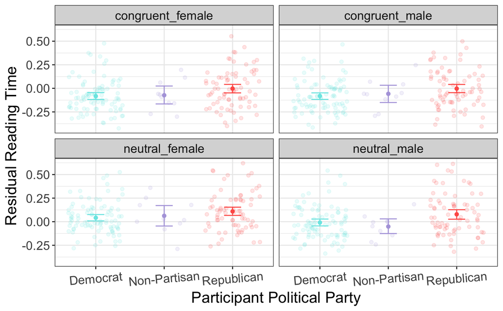

```r
maze_data_comp_means_all %>%
  filter(!is.na(poli_party)) %>%
  #filter(poli_party != "Non-Partisan") %>%
  group_by(condition,poli_party) %>%
  summarize(mean_rt = mean(condition_mean), CI.Low = ci.low(condition_mean), CI.High = ci.high(condition_mean)) %>%
  mutate(YMin = mean_rt - CI.Low, YMax = mean_rt + CI.High) %>%
  ggplot(aes(x=poli_party,y=mean_rt,color=poli_party)) +
  geom_point() +
  geom_point(data=maze_data_comp_means_all, aes(x=poli_party,y=condition_mean),alpha=0.15, position="jitter") +
  geom_errorbar(aes(ymin=YMin,ymax=YMax),width=.25) +
  facet_wrap(~ condition) +
  theme_bw() +
  labs(x="Participant Political Party", y="Residual Reading Time") +
  theme(text=element_text(size=16)) +
  theme(axis.text.x = element_text(angle=5, vjust = .7)) +
  scale_color_manual(values = bran_palette) +
  theme(legend.position = "none")
```

```r
ggsave("maze_all_regions_party.png", width=7, height=5,path='/Users/branpap/Desktop/gender_processing/talks_and_papers/qp_paper/figures')
```

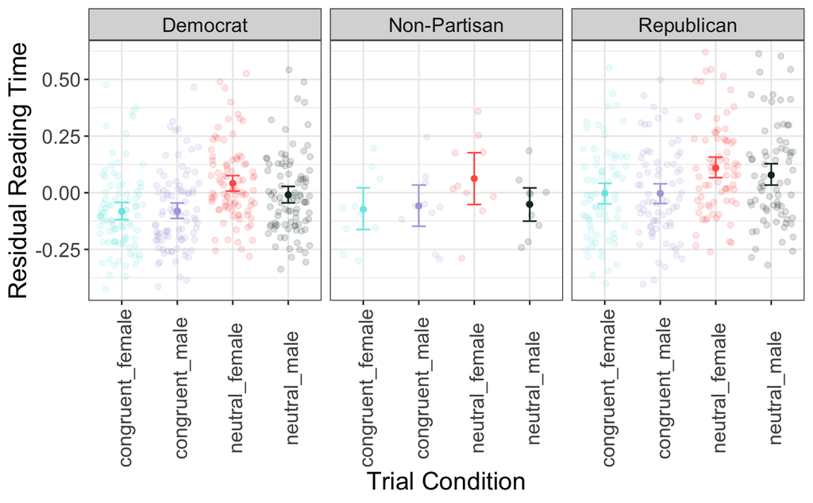

```r
maze_data_comp_means_all %>%
  filter(!is.na(poli_party)) %>%
  #filter(poli_party != "Non-Partisan") %>%
  group_by(condition,poli_party) %>%
  summarize(mean_rt = mean(condition_mean), CI.Low = ci.low(condition_mean), CI.High = ci.high(condition_mean)) %>%
  mutate(YMin = mean_rt - CI.Low, YMax = mean_rt + CI.High) %>%
  ggplot(aes(x=condition,y=mean_rt,color=condition)) +
  geom_point() +
  geom_point(data=maze_data_comp_means_all, aes(x=condition,y=condition_mean),alpha=0.15, position="jitter") +
  geom_errorbar(aes(ymin=YMin,ymax=YMax),width=.25) +
  facet_wrap(~ poli_party) +
  theme_bw() +
  labs(x="Trial Condition", y="Residual Reading Time") +
  theme(text=element_text(size=16)) +
  theme(axis.text.x = element_text(angle=90, vjust = .7)) +
  scale_color_manual(values = bran_palette) +
  theme(legend.position = "none")
```

```r
ggsave("maze_all_regions_condition.png", width=7, height=5,path='/Users/branpap/Desktop/gender_processing/talks_and_papers/qp_paper/figures')
```

```r
model <- lmer(resid_rt~poli_party + subject_information.age + condition + (1|name) + (1|lexeme) + (1|workerid))
```

```
Error in eval(predvars, data, env) : object 'resid_rt' not found
```

```r
summary(model)
```

[output not shown]